# 880HW1

## Biostat 880 HW1

### Problem 1.6

```python
import numpy as np
import pandas as pd
import matplotlib.pyplot as plt
from scipy import stats
```

```python
### generate the data set of three columns, where each row is a triple of independent normal random variables
np.random.seed(999)
rows = 100
columns = 3
data = np.random.randn(rows, columns)
```

```python
### Define the function of constructing dataset according the conditions
def construct_dataset(a, b):
    df = pd.DataFrame(data)
    df.columns = ['z_i1', 'z_i2', 'z_i3']

    y_i1 = 1 + df['z_i1']
    y_i2 = 5 + 2 * df['z_i1'] + df['z_i2']
    u_i = a * (y_i1 - 1) + b * (y_i2 - 5) + df['z_i3']

    m_i2 = []
    for i in range(rows):
      if u_i[i] < 0:
        m_i2.append(1)
      else:
        m_i2.append(0)

    y_i2_miss = []
    for i in range(rows):
      if m_i2[i] == 1:
        y_i2_miss.append(np.nan)
      else:
        y_i2_miss.append(y_i2[i])

    df['y_i1'] = y_i1
    df['y_i2'] = y_i2
    df['u_i'] = u_i
    df['m_i2'] = m_i2
    df['y_i2_miss'] = y_i2_miss

    return(df)
```

#### Part(a)

We first extract the data that m_i2 = 0 and m_i2 = 1, seperately, and then we will draw plots for Y1 and Y2 under different cases

```python
### We first extract the data that m_i2 = 0 and m_i2 = 1, seperately
complete_case = df[df['m_i2'] == 0]
incomplete_case = df[df['m_i2'] == 1]
```

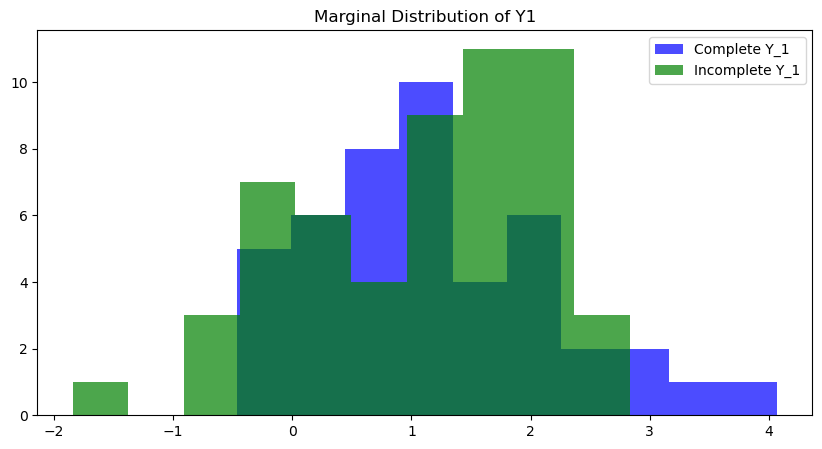

```python
## The plot for Y_1 under different cases
plt.figure(figsize = (10, 5))
plt.hist(complete_case['y_i1'], bins = 10, alpha = 0.7, label = 'Complete Y_1', color = 'blue')
plt.hist(incomplete_case['y_i1'], bins = 10, alpha = 0.7, label = 'Incomplete Y_1', color = 'green')
plt.title('Marginal Distribution of Y1')
plt.legend()
```

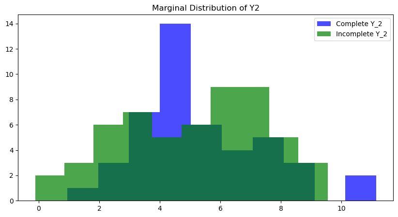

```python
## The plot for Y_2 under different cases
plt.figure(figsize = (10, 5))
plt.hist(complete_case['y_i2'], bins = 10, alpha = 0.7, label = 'Complete Y_2', color = 'blue')
plt.hist(incomplete_case['y_i2'], bins = 10, alpha = 0.7, label = 'Incomplete Y_2', color = 'green')
plt.title('Marginal Distribution of Y2')
plt.legend()
```

Notice that since we are under the case of a = 0 and b = 0, which means the missing mechanism for $y_{i2}$ only depends on the value of $z_{i3}$, but since $u$ is a latent variable, so this is MCAR, that the missing does not depend on both $Y_1$ and $Y_2$

#### Part(b)

Now we will present the two sample t-test for $Y_1$ in different group

```python
t_stat, p_value = stats.ttest_ind(complete_case['y_i1'], incomplete_case['y_i1'])
print("The t_stat is:", t_stat, "and the p_value is:", p_value)
```

```
The t_stat is: 0.7124170720870086 and the p_value is: 0.4778992853701389
```

I think that the above testing result shows that we cannot reject the null hypothesis that means of $Y_1$ is the same, which may indicate that the missing mechanism does not depend on $Y_1$. And we cannot make any statement about whether there is evidence of mechanism are not MCAR, MAR, and MNAR because we did not know how do $Y_2$ impact the missing mechanism.

#### Part(c)

(i)(a)

```python
## We again cosntruct a dataset where a = 2, and b = 0
df_1 = construct_dataset(a = 2, b = 0)
```

```python
complete_case_1 = df_1[df_1['m_i2'] == 0]
incomplete_case_1 = df_1[df_1['m_i2'] == 1]
```

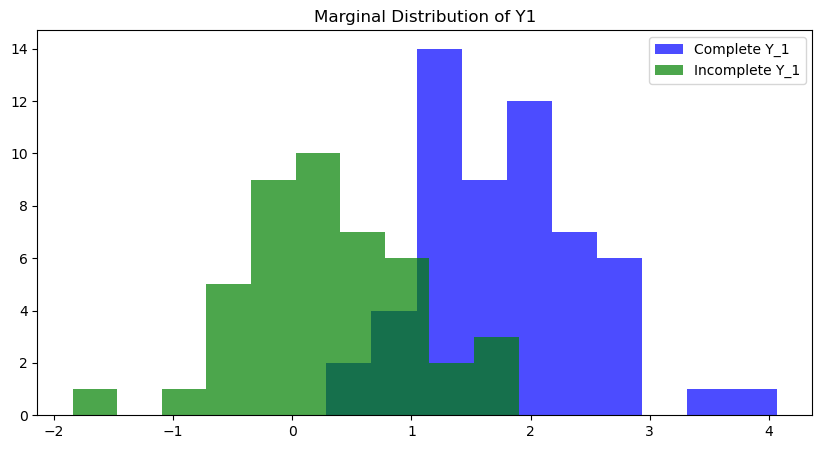

```python
## The plot for Y_1 under different cases
plt.figure(figsize = (10, 5))
plt.hist(complete_case_1['y_i1'], bins = 10, alpha = 0.7, label = 'Complete Y_1', color = 'blue')
plt.hist(incomplete_case_1['y_i1'], bins = 10, alpha = 0.7, label = 'Incomplete Y_1', color = 'green')
plt.title('Marginal Distribution of Y1')
plt.legend()
```

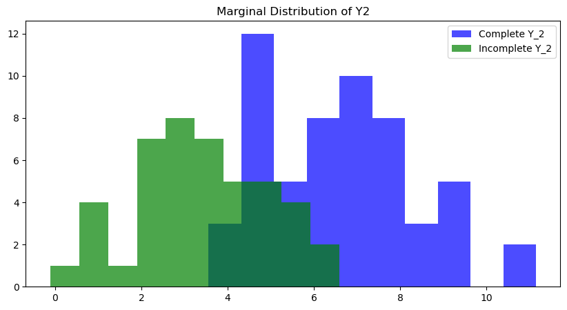

```python
## The plot for Y_2 under different cases
plt.figure(figsize = (10, 5))
plt.hist(complete_case_1['y_i2'], bins = 10, alpha = 0.7, label = 'Complete Y_2', color = 'blue')
plt.hist(incomplete_case_1['y_i2'], bins = 10, alpha = 0.7, label = 'Incomplete Y_2', color = 'green')
plt.title('Marginal Distribution of Y2')
plt.legend()
```

Since the coefficient $a$ is not 0, which means that the missing value for $Y_2$ depends only on $Y_1$ as $b = 0$, and we never observed for $z_3$, so the mechanism is MAR

(i)(b)

```python
t_stat_1, p_value_1 = stats.ttest_ind(complete_case_1['y_i1'], incomplete_case_1['y_i1'])
print("The t_stat is:", t_stat_1, "and the p_value is:", p_value_1)
```

```
The t_stat is: 10.286347558342179 and the p_value is: 2.895830511775322e-17
```

Notice that since the t_test is 10.28 which is largem and the p-value is far below than 0.01, we will reject the null hypothesis and claim that $Y_1$ in different groups has different mean. So this indicate the mechanism is not MCAR, and we may claim that the mechanism should be MAR.

(ii)(a)

```python
df_2 = construct_dataset(a = 0, b = 5)
```

```python
complete_case_2 = df_2[df_2['m_i2'] == 0]
incomplete_case_2 = df_2[df_2['m_i2'] == 1]
```

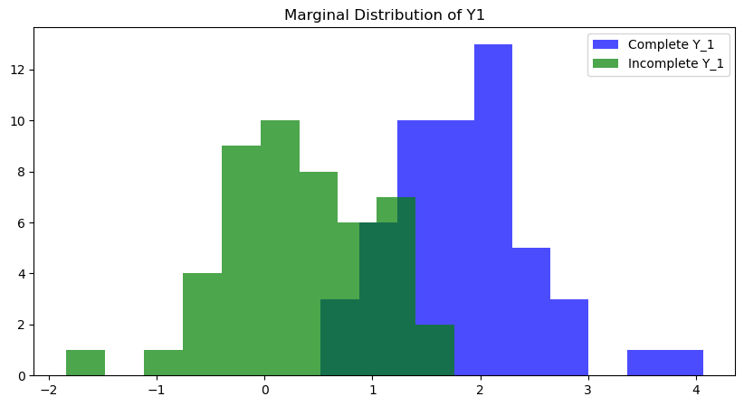

```python
## The plot for Y_1 under different cases
plt.figure(figsize = (10, 5))
plt.hist(complete_case_2['y_i1'], bins = 10, alpha = 0.7, label = 'Complete Y_1', color = 'blue')
plt.hist(incomplete_case_2['y_i1'], bins = 10, alpha = 0.7, label = 'Incomplete Y_1', color = 'green')
plt.title('Marginal Distribution of Y1')
plt.legend()
```

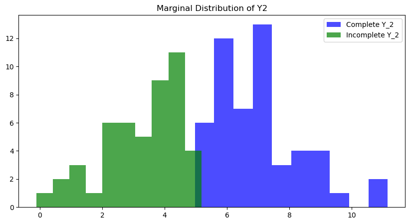

```python
## The plot for Y_2 under different cases
plt.figure(figsize = (10, 5))
plt.hist(complete_case_2['y_i2'], bins = 10, alpha = 0.7, label = 'Complete Y_2', color = 'blue')
plt.hist(incomplete_case_2['y_i2'], bins = 10, alpha = 0.7, label = 'Incomplete Y_2', color = 'green')
plt.title('Marginal Distribution of Y2')
plt.legend()
```

The mechanism should be MNAR because the missing value of $Y_2$ depends on $Z_1$, and in fact $Y_1$ also depends on $Z_1$ even though $a = 0$. Thus, since the missing value depends on $Y_2$, we may conlcude that the mechanism is MNAR.

```python
t_stat_2, p_value_2 = stats.ttest_ind(complete_case_2['y_i1'], incomplete_case_2['y_i1'])
print("The t_stat is:", t_stat_2, "and the p_value is:", p_value_2)
```

```
The t_stat is: 11.189493855151834 and the p_value is: 3.243628896980342e-19
```

Thus. according to the test result, we may conclude that the mechanism should be MAR since we never observe all $Y_2$ and we cannot claim as a god that in fact the data has MNAR. We can never conclude that the mechanism is MCAR, and we also cannot determine whether the mechanism is MNAR because we can't see full Y2